# Practical Machine Learning Assignment

Sébastien Durand

9th February 2016

## Synopsis

**github repo**: https://github.com/sebastid/PracticalMachineLearning  
**gh-pages link**: https://sebastid.github.io/PracticalMachineLearning/PracticalMachineLearningAssignment.html

This the *Practical Machine Learning Assignment* report that shows how to predict how well people do a particular physical activity using machine learning.

In this report, we will re-use data measured from accelerometers on the belt, forearm, arm, and dumbell of 6 young health participants who were asked to perform one set of 10 repetitions of the Unilateral Dumbbell Biceps Curl in five different fashions: exactly according to the specification (Class A), throwing the elbows to the front (Class B), lifting the dumbbell only halfway (Class C), lowering the dumbbell only halfway (Class D) and throwing the hips to the front (Class E).

It will describe:

1. how the fitted model was built.
2. how cross validation was used.
3. what the expected out of sample error should.
4. justifications for chosen decisions.

The final prediction model will also be used to predict 20 different test cases.

The data for this project assignment come from this source: [Weight Lifting Exercises Dataset](http://groupware.les.inf.puc-rio.br/har). The reader is encouraged to read the following paper for further details: [Wearable Computing: Accelerometers’ Data Classification of Body Postures and Movements](http://groupware.les.inf.puc-rio.br/work.jsf?p1=10335)

## Data loading & clean up

The training data for this project are available here: https://d396qusza40orc.cloudfront.net/predmachlearn/pml-training.csv

The test data are available here: https://d396qusza40orc.cloudfront.net/predmachlearn/pml-testing.csv

Let’s start by loading the training and final test datasets directly from the website:

```r
training_file_url <- "https://d396qusza40orc.cloudfront.net/predmachlearn/pml-training.csv"
download.file(training_file_url, dest="pml-training.csv",method="curl")
plm_training_df <- read.csv("./pml-training.csv")

training_file_url <- "https://d396qusza40orc.cloudfront.net/predmachlearn/pml-testing.csv"
download.file(training_file_url, dest="pml-testing.csv",method="curl")
plm_testing_df <- read.csv("./pml-testing.csv")

dim(plm_training_df)
```

```
## [1] 19622   160
```

```r
dim(plm_testing_df)
```

```
## [1]  20 160
```

The training dataset contains **19622** rows and **160** variables including the output **‘classe’** variable to predict. The testing dataset only contains **20** rows corresponding to the test input rows for the final prediction to perform(project Quiz). Let’s proceed with some exploratory analysis:

```r
str(plm_training_df)
```

```
## 'data.frame':    19622 obs. of  160 variables:
##  $ X                       : int  1 2 3 4 5 6 7 8 9 10 ...
##  $ user_name               : Factor w/ 6 levels "adelmo","carlitos",..: 2 2 2 2 2 2 2 2 2 2 ...
##  $ raw_timestamp_part_1    : int  1323084231 1323084231 1323084231 1323084232 1323084232 1323084232 1323084232 1323084232 1323084232 1323084232 ...
##  $ raw_timestamp_part_2    : int  788290 808298 820366 120339 196328 304277 368296 440390 484323 484434 ...
##  $ cvtd_timestamp          : Factor w/ 20 levels "02/12/2011 13:32",..: 9 9 9 9 9 9 9 9 9 9 ...
##  $ new_window              : Factor w/ 2 levels "no","yes": 1 1 1 1 1 1 1 1 1 1 ...
##  $ num_window              : int  11 11 11 12 12 12 12 12 12 12 ...
##  $ roll_belt               : num  1.41 1.41 1.42 1.48 1.48 1.45 1.42 1.42 1.43 1.45 ...
##  $ pitch_belt              : num  8.07 8.07 8.07 8.05 8.07 8.06 8.09 8.13 8.16 8.17 ...
##  $ yaw_belt                : num  -94.4 -94.4 -94.4 -94.4 -94.4 -94.4 -94.4 -94.4 -94.4 -94.4 ...
##  $ total_accel_belt        : int  3 3 3 3 3 3 3 3 3 3 ...
##  $ kurtosis_roll_belt      : Factor w/ 397 levels "","-0.016850",..: 1 1 1 1 1 1 1 1 1 1 ...
##  $ kurtosis_picth_belt     : Factor w/ 317 levels "","-0.021887",..: 1 1 1 1 1 1 1 1 1 1 ...
##  $ kurtosis_yaw_belt       : Factor w/ 2 levels "","#DIV/0!": 1 1 1 1 1 1 1 1 1 1 ...
```

[output cut: 86 more lines]

The *str* command output shows that the dataset is not very tidy and contains a lot of missing data and will require data cleaning. Let’s have a look at the classe distribution per user name and also per timestamp date:

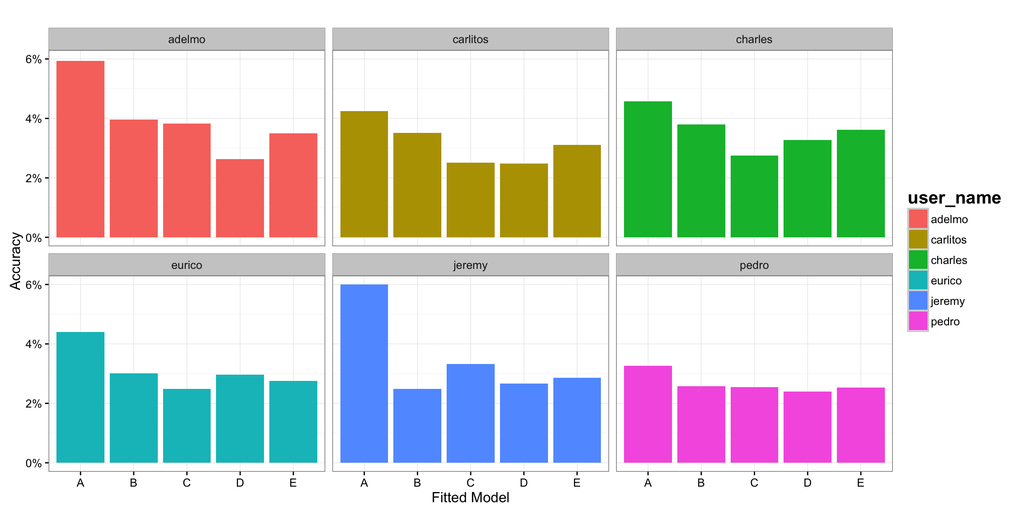

```r
library(ggplot2); library(scales)
g <- ggplot(plm_training_df,aes(x=classe,fill=user_name))+geom_bar(aes(y = (..count..)/sum(..count..)))+facet_wrap(~user_name)+scale_y_continuous(labels = percent)
g <- g + theme_bw() + theme(legend.title = element_text(colour="black", size=15, face="bold"))
g <- g + xlab("Fitted Model") + ylab("Accuracy") + ggtitle("")
g
```

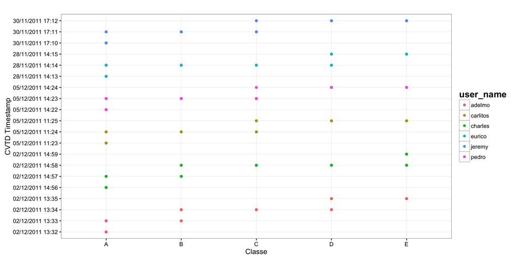

```r
g <- ggplot(data=plm_training_df,aes(x=cvtd_timestamp,y=classe,color=user_name))+geom_point()+coord_flip()
g <- g + theme_bw() + theme(legend.title = element_text(colour="black", size=15, face="bold"))
g <- g + xlab("CVTD Timestamp") + ylab("Classe") + ggtitle("")
g
```

The plot above shows that the timestamp related variables are grouped together for each user. The first cleanup task is to ignore any timestamp variables but to keep the user name variable and create new co-variate variables from it (e.g. one hot encoding with *dummyVars*):

```r
library(caret)
dummies <- dummyVars(~ user_name, data=plm_training_df)
plm_training_df <- cbind(plm_training_df,predict(dummies,newdata=plm_training_df))
plm_testing_df <- cbind(plm_testing_df,predict(dummies,newdata=plm_testing_df))
```

Let’s remove some variables like index X, num_window, the original user_name variable and any timestamp related variables (the idea is to initially use sensor measurement variables assigned to each user; if the results are not satisfactory then we’ll review this later on):

```r
labels_to_remove <- c("user_name","X","cvtd_timestamp",
                      "raw_timestamp_part_1","raw_timestamp_part_2","num_window")
plm_training_df <- plm_training_df[, -match(labels_to_remove, names(plm_training_df))]
plm_testing_df <- plm_testing_df[,-match(labels_to_remove, names(plm_testing_df))]
```

Let’s look at the extent of the missing data:

```r
train_has_na_vars <- names(plm_training_df)[apply(plm_training_df, 2, function(x) sum(is.na(x))>0)]
test_has_na_vars <- names(plm_testing_df)[apply(plm_testing_df, 2, function(x) sum(is.na(x))>0)]
has_na_vars <- union(train_has_na_vars,test_has_na_vars)
```

There are **100** variables containing missing data. The quantile command below shows that most these variable rows represents around 97.9% of missing data:

```r
quantile(colMeans(is.na(plm_training_df[,has_na_vars])))
```

```
##        0%       25%       50%       75%      100%
## 0.0000000 0.0000000 0.9793089 0.9793089 0.9793089
```

Therefore, in order to reduce the training and testing feature space further, we’ll ignore all variables containing missing values and remove them from the training and testing datasets:

```r
plm_training_df <- plm_training_df[,-match(has_na_vars,names(plm_training_df))]
plm_testing_df <- plm_testing_df[,-match(has_na_vars,names(plm_testing_df))]
cat(sprintf("Missing value Nb(training): %d, (Testing): %d\n",sum(is.na(plm_training_df)),sum(is.na(plm_testing_df))))
```

```
## Missing value Nb(training): 0, (Testing): 0
```

Lastly, we’ll remove any *near zero variance* variables with the *nearZeroVar* command. The tidied up dataset list of variables is shown below:

```r
nsv <- nearZeroVar(plm_training_df,saveMetrics=TRUE)
nsv_vars <- names(plm_training_df)[nsv$nzv]
plm_training_df <- plm_training_df[,-match(nsv_vars,names(plm_training_df))]
plm_testing_df <- plm_testing_df[,-match(nsv_vars,names(plm_testing_df))]
str(plm_training_df)
```

```
## 'data.frame':    19622 obs. of  59 variables:
##  $ roll_belt           : num  1.41 1.41 1.42 1.48 1.48 1.45 1.42 1.42 1.43 1.45 ...
##  $ pitch_belt          : num  8.07 8.07 8.07 8.05 8.07 8.06 8.09 8.13 8.16 8.17 ...
##  $ yaw_belt            : num  -94.4 -94.4 -94.4 -94.4 -94.4 -94.4 -94.4 -94.4 -94.4 -94.4 ...
##  $ total_accel_belt    : int  3 3 3 3 3 3 3 3 3 3 ...
##  $ gyros_belt_x        : num  0 0.02 0 0.02 0.02 0.02 0.02 0.02 0.02 0.03 ...
##  $ gyros_belt_y        : num  0 0 0 0 0.02 0 0 0 0 0 ...
##  $ gyros_belt_z        : num  -0.02 -0.02 -0.02 -0.03 -0.02 -0.02 -0.02 -0.02 -0.02 0 ...
##  $ accel_belt_x        : int  -21 -22 -20 -22 -21 -21 -22 -22 -20 -21 ...
##  $ accel_belt_y        : int  4 4 5 3 2 4 3 4 2 4 ...
##  $ accel_belt_z        : int  22 22 23 21 24 21 21 21 24 22 ...
##  $ magnet_belt_x       : int  -3 -7 -2 -6 -6 0 -4 -2 1 -3 ...
##  $ magnet_belt_y       : int  599 608 600 604 600 603 599 603 602 609 ...
##  $ magnet_belt_z       : int  -313 -311 -305 -310 -302 -312 -311 -313 -312 -308 ...
##  $ roll_arm            : num  -128 -128 -128 -128 -128 -128 -128 -128 -128 -128 ...
```

[output cut: 45 more lines]

Most of the variables above are of integer and numeric types. We could take a last cleaning step to transform all integer types to numeric, but let’s see how the prediction models cope with the training dataset as it is.

Also, there are now **59** variables including **classe** (reduced from 160). We could add another pre-rocessing step using PCA to only select the principal components with the most variance in the dataset thus reducing the input feature space further. However we would loose some interpretability on the fitted model’s learned parameters, e.g. if we wanted to get some insight on why a particular model works well.

## Models training

Six different models will be trained using a 5-folds cross validation approach. They will then be evaluated and compared against a validation (or *out-of-sample*) dataset:

1. Decision Classification Tree (rpart)
2. k-Nearest Neighbor Classifier (knn)
3. NaiveBayes classifier (nb)
4. Random Forest model (rf)
5. Linear Discriminant Analysis model(lda)
6. Generalized Boosted Regression Model (gbm)

### Cross-Validation Setup

We’ll split the input training dataset into 60% for the models training and 40% for the models testing:

```r
library(caret)
set.seed(1234)
inTrain <- createDataPartition(y=plm_training_df$classe, p=0.6, list=FALSE)
training <- plm_training_df[inTrain,]
validation <- plm_training_df[-inTrain,]

#CV setup
folds=5; repeats=1
fit_control <- trainControl(method = 'cv', number=folds, repeats=repeats, summaryFunction=defaultSummary, verboseIter = FALSE)
PP <- c("center","scale")

dim(training)
```

```
## [1] 11776    59
```

```r
dim(validation)
```

```
## [1] 7846   59
```

### Model fitting

The model fitting will be performed using the *caret::train* command using the training control defined before. With the exception of the Tree and Random Forest models, all models will be trained with a standardization pre-processing step beforehand (.i.e. preProcess=PP).

```r
tree_model <- train(classe ~ ., data=training,  method="rpart", trControl=fit_control)
rf_model <- train(classe ~ ., data=training, method="rf", trControl=fit_control, ntree=10, importance=TRUE)
knn_model <- train(classe ~ ., data=training, method="knn", trControl=fit_control, preProcess=PP)
nb_model <- train(classe ~ ., data=training, method="nb", trControl=fit_control, preProcess=PP)
lda_model <- train(classe ~ ., data=training, method="lda", trControl=fit_control, preProcess=PP)
gbm_model <- train(classe ~ ., data=training, method="gbm", trControl=fit_control, preProcess=PP, verbose=FALSE)
```

### Evaluation of the trained models against the validation dataset

We’ll use a function(**score_acc**) to score the accuracy of each fitted model against the validation dataset:

```r
score_acc <- function(pred,test)
{
  tbl <- table(pred,test)
  sum(diag(tbl))/sum(tbl)
}

all_models <- list(tree_model, knn_model, nb_model, rf_model, lda_model, gbm_model)
names(all_models) <- sapply(all_models, function(x) x$method)
training_accuracies <- sapply(all_models, function(x) x$accuracy)
trn_acc <- sort(sapply(all_models, function(x) max(score_acc(predict(x,training),training$classe))))
test_acc <- sort(sapply(all_models, function(x) max(score_acc(predict(x,validation),validation$classe))))
trn_acc
```

```
##     rpart       lda        nb       gbm       knn        rf
## 0.4988961 0.7362432 0.7438859 0.9730808 0.9791950 0.9997452
```

```r
test_acc
```

```
##     rpart       lda        nb       gbm       knn        rf
## 0.4904410 0.7329850 0.7388478 0.9573031 0.9587051 0.9840683
```

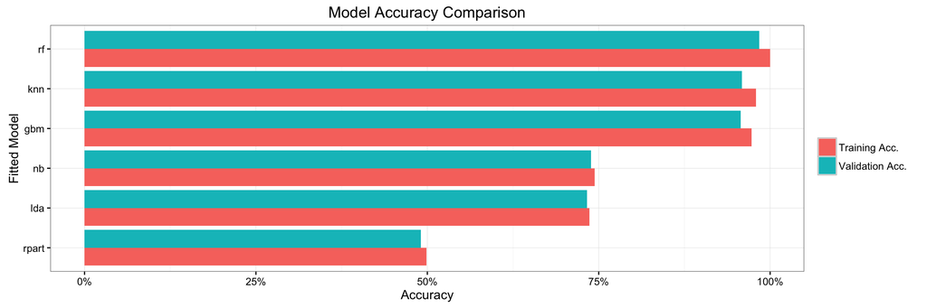

```r
models <- names(test_acc)
acc_res_df <- data.frame(trn_acc=trn_acc[models],test_acc=test_acc[models],models)
names(acc_res_df) <- c("Training Acc.", "Validation Acc.", "FittedModel")
library(reshape2)
acc_plt <- melt(acc_res_df, id.vars = c('FittedModel'))
g <- ggplot(data=acc_plt,aes(x=factor(FittedModel,levels=names(test_acc))))
g <- g + geom_bar(aes(y=value,fill=variable),position="dodge",stat="identity")+coord_flip()
g <- g + xlab("Fitted Model") + ylab("Accuracy") +scale_y_continuous(labels = percent)
g <- g + theme_bw() + theme(legend.title = element_text(colour="black", size=15, face="bold"))
g <- g + scale_fill_discrete("") + ggtitle("Model Accuracy Comparison")
g
```

The plot above shows that the most accurate model tested on the validation is the **Random Forest** model, closely followed by the **GBM** and **kNN** models. The **NaiveBayes** and **LDA** models are not so accurate but still acceptable(could be used in an ensemble model). The least accurate model is the **rpart** tree classification model.

## Selection of the prediction model method for the quiz submission

The most accurate model, e.g. the Random Forest model, will be used for the prediction of the 20 quiz questions. Its confusion matrix and stats are shown below:

```r
confusionMatrix(predict(rf_model,validation),validation$classe)
```

```
## Confusion Matrix and Statistics
##
##           Reference
## Prediction    A    B    C    D    E
##          A 2228   22    0    0    0
##          B    2 1483   23    3    7
##          C    1   12 1328   19    2
##          D    1    1   17 1262    8
##          E    0    0    0    2 1425
##
## Overall Statistics
##
##                Accuracy : 0.9847
##                  95% CI : (0.9817, 0.9873)
##     No Information Rate : 0.2845
##     P-Value [Acc > NIR] : < 2.2e-16
##
##                   Kappa : 0.9806
##  Mcnemar's Test P-Value : NA
##
## Statistics by Class:
##
##                      Class: A Class: B Class: C Class: D Class: E
## Sensitivity            0.9982   0.9769   0.9708   0.9813   0.9882
## Specificity            0.9961   0.9945   0.9948   0.9959   0.9997
## Pos Pred Value         0.9902   0.9769   0.9750   0.9791   0.9986
## Neg Pred Value         0.9993   0.9945   0.9938   0.9963   0.9974
## Prevalence             0.2845   0.1935   0.1744   0.1639   0.1838
## Detection Rate         0.2840   0.1890   0.1693   0.1608   0.1816
## Detection Prevalence   0.2868   0.1935   0.1736   0.1643   0.1819
## Balanced Accuracy      0.9971   0.9857   0.9828   0.9886   0.9939
```

Its error evaluation on the out-of-sample / validation dataset is obtained using the *score_err* function which normalizes the sum of the upper and lower triangle values of the above Confusion Matrix:

```r
score_err <- function(pred,test)
{
  tbl <- table(pred,test)
  (sum(tbl[upper.tri(tbl)])+sum(tbl[lower.tri(tbl)]))/sum(tbl)
}

oos_err <- score_err(predict(rf_model,validation),validation$classe)
oos_err
```

```
## [1] 0.01542187
```

The *out-of-sample error* is **1.54%** on the validation set.

## Tuning of the prediction model

Although the *out-of-sample error* is very good (almost too good), this could be improved further by narrowing down the list of input variables. This is done by identifying those with the greatest influence on the outcome, we’ll use the *varImpPlot* command:

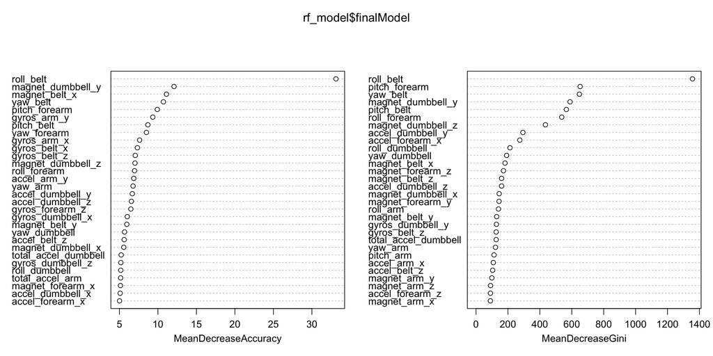

```r
library(randomForest)
varimp <- varImpPlot(rf_model$finalModel)
```

```r
imp_df<-data.frame(varimp)
imp_names <-rownames(imp_df)[order(desc(imp_df$MeanDecreaseGini))]
```

```r
rf_formula <- reformulate(imp_names[1:20], response = "classe")
rf_formula
```

[output not shown]

Let’s train few more *Random Forest* model with the 20 variables and different tree number values (10,100 and 500) and re-evaluate their accuracies and *out-of-sample* errors on the validation set:

```r
rf10_model <- train(rf_formula, data=training, method="rf", trControl=fit_control, ntree=10, importance=TRUE)
rf100_model <- train(rf_formula, data=training, method="rf", trControl=fit_control, ntree=100, importance=TRUE)
rf500_model <- train(rf_formula, data=training, method="rf", trControl=fit_control, ntree=500, importance=TRUE)

acc10 <- score_acc(predict(rf10_model,validation),validation$classe)
err10 <- score_err(predict(rf10_model,validation),validation$classe)
acc100 <- score_acc(predict(rf100_model,validation),validation$classe)
err100 <- score_err(predict(rf100_model,validation),validation$classe)
acc500 <- score_acc(predict(rf500_model,validation),validation$classe)
err500 <- score_err(predict(rf500_model,validation),validation$classe)
data.frame(TreeNb=c(10,100,500),Accuracy=c(acc10,acc100,acc500),Error=c(err10,err100,err500))
```

```
##   TreeNb  Accuracy       Error
## 1     10 0.9817742 0.017206220
## 2    100 0.9905684 0.009686464
## 3    500 0.9917155 0.008284476
```

## Conclusion and prediction for the course quiz submission

In conclusion, we’ve trained many types of classifiers and chose a **Random Forest** as being the most accurate. We then tuned the **Random Forest** model with the 20 most influencing variables on accuracy and different values of tree numbers. The final **Random Forest** model will use 500 trees achieving an *out-of-sample error* of **0.83%**.

Here are its 20 predictions for the course final quiz submission:

```r
predict(rf500_model, plm_testing_df)
```

```
##  [1] B A B A A E D B A A B C B A E E A B B B
## Levels: A B C D E
```